# Open APC Sweden - Statistics

This is an example of statistics from the pilot project Open APC Sweden, aiming at gathering data about article processing charges (APC’s) paid by Swedish universities. The statistics cover journal articles published mainly between 2014 and **2 017** from a few pilot contributors. Please see the [project wiki](https://github.com/Kungbib/openapc-se/wiki) for more information about the project and instructions on how to contribute.

## Contributing organisations and publishers

These Swedish universities have reported APC costs for their articles so far:

| Delivering universities |
| --- |
| Dalarna University College |
| University of Gothenburg |
| University College West |
| KTH Royal Institute of Technology |
| Linköping University |
| Luleå University of Technology |
| Malmö University |
| Örebro University |
| Swedish University of Agricultural Sciences |
| Stockholm University |

A number of publishers have also supplied Open APC Sweden with data:

| Publishers |
| --- |
| Springer |
| Taylor & Francis |
| Karger |
| IOP Publishing |
| Copernicus |

This publisher-supplied data leads to publishing costs being reported for a number of Swedish research institutions which not yet have supplied us with data actively.

## Dataset

Information on both open access journal articles, open access publication of articles in toll-access journals (‘hybrid’) and articles published within current Swedish Offset deals are provided. You may view the dataset at the [project page in GitHub](https://github.com/Kungbib/openapc-se/blob/master/data/apc_se.csv).

## Open Access Articles (Total: ‘gold’, ‘hybrid’ and ‘offset’)

At the moment, the dataset contains the following information:

- Number of articles: **4 807**
- Total expenditure: **8 974 620 €**
- Average fee: **1 867 €**
- Median fee: **2 200 €**

Articles and APC costs per institution:

| Organisation | Articles | Fees paid (€) | Mean APC (€) | Median APC (€) |
| --- | --- | --- | --- | --- |
| Blekinge Institute of Technology | 10 | 22 000 | 2 200 | 2 200 |
| Borås University College | 9 | 19 550 | 2 172 | 2 200 |
| Chalmers University of Technology | 125 | 264 540 | 2 116 | 2 200 |
| Dalarna University College | 43 | 78 739 | 1 831 | 1 765 |
| Gävle University College | 8 | 17 600 | 2 200 | 2 200 |
| Halmstad University College | 6 | 13 200 | 2 200 | 2 200 |
| Institute Mittag-Leffler | 1 | 2 200 | 2 200 | 2 200 |
| Jönköping University Foundation | 10 | 22 000 | 2 200 | 2 200 |
| Karlstad University | 21 | 46 200 | 2 200 | 2 200 |
| Karolinska Institutet | 252 | 509 040 | 2 020 | 2 200 |
| Kristianstad University College | 14 | 30 800 | 2 200 | 2 200 |
| KTH Royal Institute of Technology | 484 | 786 795 | 1 626 | 1 905 |
| Linköping University | 341 | 631 503 | 1 852 | 2 132 |
| Linnaeus University | 34 | 73 230 | 2 154 | 2 200 |
| Luleå University of Technology | 137 | 239 963 | 1 752 | 2 200 |
| Lund University | 359 | 743 745 | 2 072 | 2 200 |
| Malmö University | 50 | 85 442 | 1 709 | 2 007 |
| Medical Products Agency | 1 | 2 200 | 2 200 | 2 200 |
| Mid Sweden University | 12 | 26 400 | 2 200 | 2 200 |
| Mälardalen University College | 18 | 39 600 | 2 200 | 2 200 |
| Skövde University College | 6 | 13 200 | 2 200 | 2 200 |
| Stockholm School of Economics | 6 | 13 200 | 2 200 | 2 200 |
| Stockholm University | 710 | 1 379 205 | 1 943 | 2 142 |
| Swedish Defence Research Agency | 5 | 11 000 | 2 200 | 2 200 |
| Swedish Museum of Natural History | 11 | 24 200 | 2 200 | 2 200 |
| Swedish National Road and Transport Research Institute | 1 | 2 200 | 2 200 | 2 200 |
| Swedish School of Sport and Health Sciences | 1 | 2 200 | 2 200 | 2 200 |
| Swedish University of Agricultural Sciences | 774 | 1 333 735 | 1 723 | 1 624 |
| Södertörns University College | 7 | 15 400 | 2 200 | 2 200 |
| Umeå University | 156 | 315 544 | 2 023 | 2 200 |
| University College West | 24 | 44 063 | 1 836 | 2 200 |
| University of Gothenburg | 744 | 1 401 538 | 1 884 | 2 118 |
| Uppsala University | 279 | 504 438 | 1 808 | 2 200 |
| Örebro University | 148 | 259 950 | 1 756 | 1 952 |

## Articles in Open Access journals (‘gold OA’)

At the moment, the dataset contains the following information on articles in open access journals:

- Number of articles: **1 733**
- Total expenditure: **2 249 208 €**
- Average fee: **1 298 €**
- Median fee: **1 320 €**
- Share of articles with no fees: **5.8 %**

Articles and APC costs per institution:

[output not shown]

## OA articles in toll-access journals (‘hybrid OA’), Offset articles excluded

In many toll-access journals some of the articles are open access after a fee has been paid. This model is often called ‘hybrid open access’. The dataset covers the following data on hybrid open access articles:

The following institutions have contributed its expenditures for hybrid open access.

| Organisation | Articles | Fees paid (€) | Mean APC (€) | Median APC (€) | Share of articles w/o fee (%) |
| --- | --- | --- | --- | --- | --- |
| Borås University College | 1 | 1 950 | 1 950 | 1 950 | 0 |
| Chalmers University of Technology | 7 | 16 723 | 2 389 | 2 429 | 0 |
| Dalarna University College | 13 | 33 705 | 2 593 | 2 690 | 0 |
| Karolinska Institutet | 25 | 38 269 | 1 531 | 1 473 | 0 |
| KTH Royal Institute of Technology | 93 | 163 912 | 1 762 | 1 744 | 3 |
| Linköping University | 55 | 112 804 | 2 051 | 2 132 | 0 |
| Luleå University of Technology | 32 | 67 536 | 2 110 | 2 290 | 0 |
| Lund University | 37 | 73 450 | 1 985 | 2 132 | 0 |
| Malmö University | 10 | 22 099 | 2 210 | 2 349 | 0 |
| Stockholm University | 303 | 670 059 | 2 211 | 2 275 | 0 |
| Swedish University of Agricultural Sciences | 219 | 515 864 | 2 356 | 2 315 | 0 |
| Umeå University | 23 | 45 340 | 1 971 | 2 132 | 0 |
| University College West | 4 | 8 395 | 2 099 | 2 022 | 0 |
| University of Gothenburg | 201 | 480 717 | 2 392 | 2 500 | 0 |
| Uppsala University | 26 | 53 226 | 2 047 | 2 132 | 0 |
| Örebro University | 46 | 94 252 | 2 049 | 2 150 | 0 |

## OA articles in offset deals

In offset deals a total number of articles is agreed upon, together with a license fee. The dataset covers the following data on offset deal articles:

- Publishers with current offset deals: **Springer**
- Number of articles: **1 927**

The following institutions have contributed to offset deals.

| Organisation | Articles |
| --- | --- |
| Blekinge Institute of Technology | 10 |
| Borås University College | 8 |
| Chalmers University of Technology | 110 |
| Dalarna University College | 3 |
| Gävle University College | 8 |
| Halmstad University College | 6 |
| Institute Mittag-Leffler | 1 |
| Jönköping University Foundation | 10 |
| Karlstad University | 21 |
| Karolinska Institutet | 212 |
| Kristianstad University College | 14 |
| KTH Royal Institute of Technology | 145 |
| Linköping University | 118 |
| Linnaeus University | 33 |
| Luleå University of Technology | 54 |
| Lund University | 290 |
| Malmö University | 17 |
| Medical Products Agency | 1 |
| Mid Sweden University | 12 |
| Mälardalen University College | 18 |
| Skövde University College | 6 |
| Stockholm School of Economics | 6 |
| Stockholm University | 137 |
| Swedish Defence Research Agency | 5 |
| Swedish Museum of Natural History | 11 |
| Swedish National Road and Transport Research Institute | 1 |
| Swedish School of Sport and Health Sciences | 1 |
| Swedish University of Agricultural Sciences | 99 |
| Södertörns University College | 7 |
| Umeå University | 118 |
| University College West | 14 |
| University of Gothenburg | 196 |
| Uppsala University | 198 |
| Örebro University | 37 |

The following diagram shows the most used journals within the offset deal.

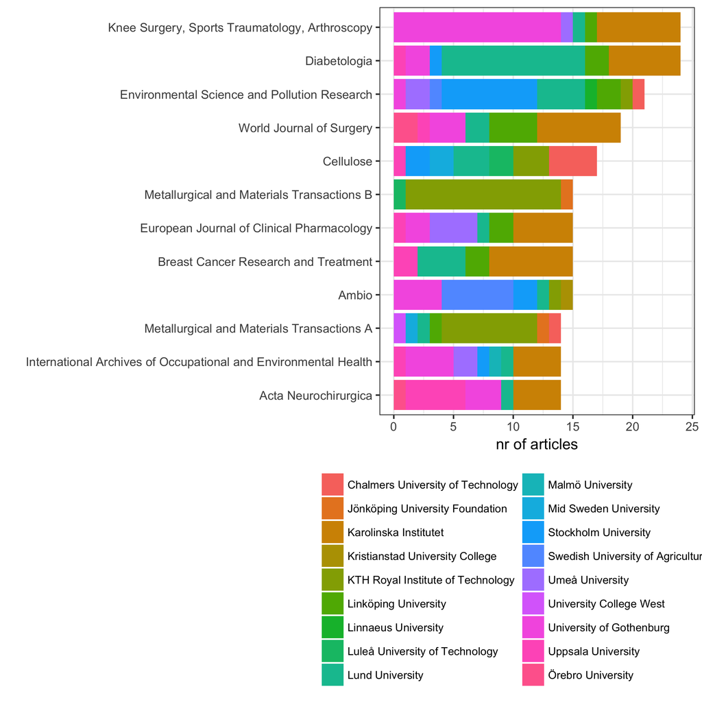

## Distribution over publishers (offset deals excluded)

### Both gold and hybrid articles (offset deals excluded)

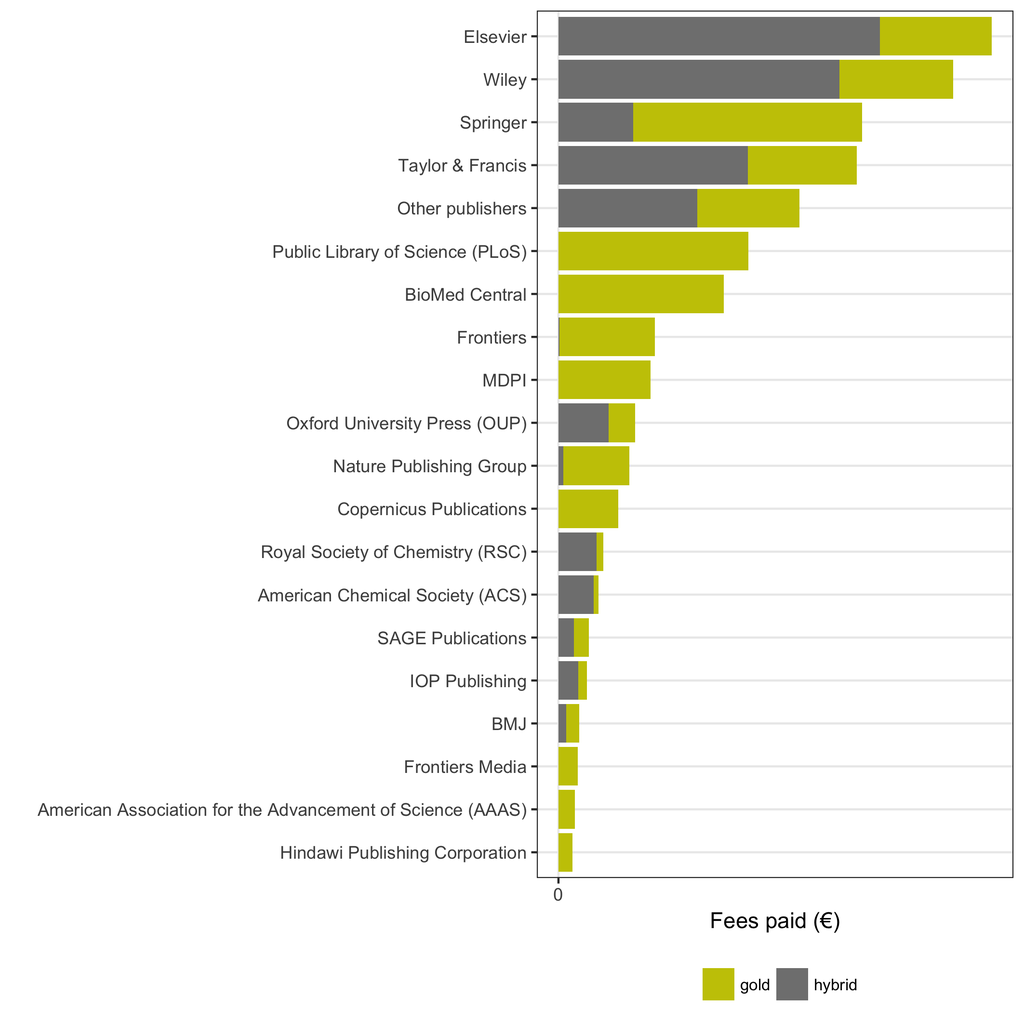

### OA journal articles (offset deals excluded)

The ten largest publishers of OA journals in terms of total APCs paid by delivering organisations (a subset of the whole dataset).

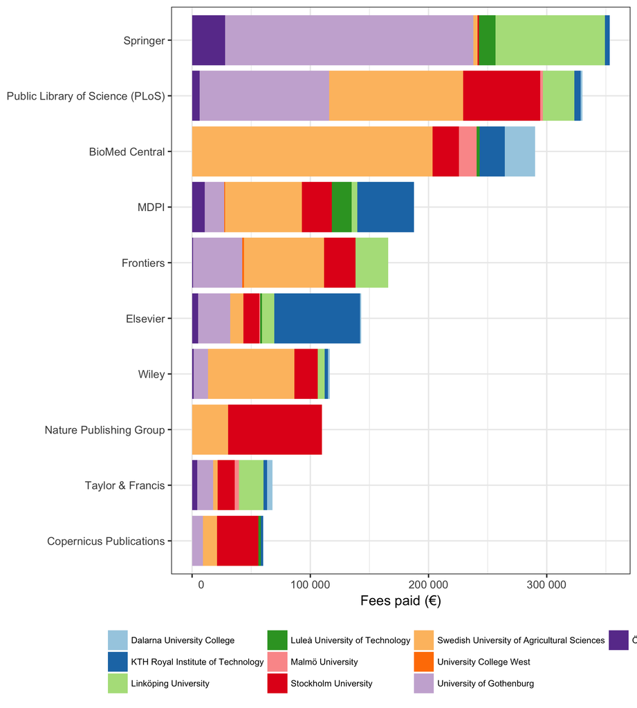

### Hybrid OA articles in toll access journals (offset deals excluded)

APC fees paid per publisher with indication of contribution from each university.

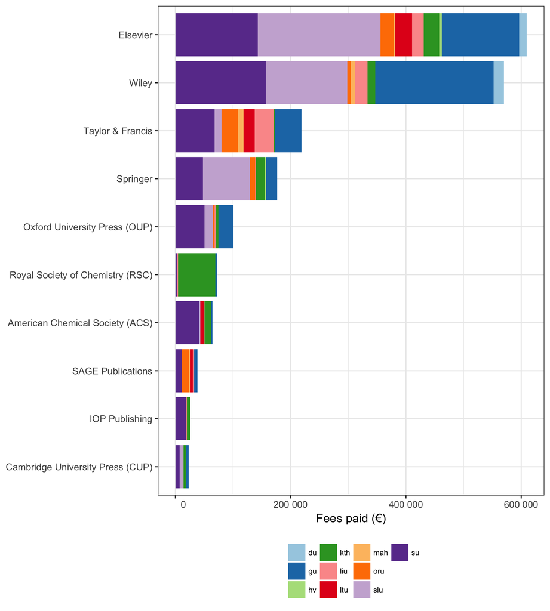

## Fees and average APC paid per organisation (only delivering universities, offset deals excluded)

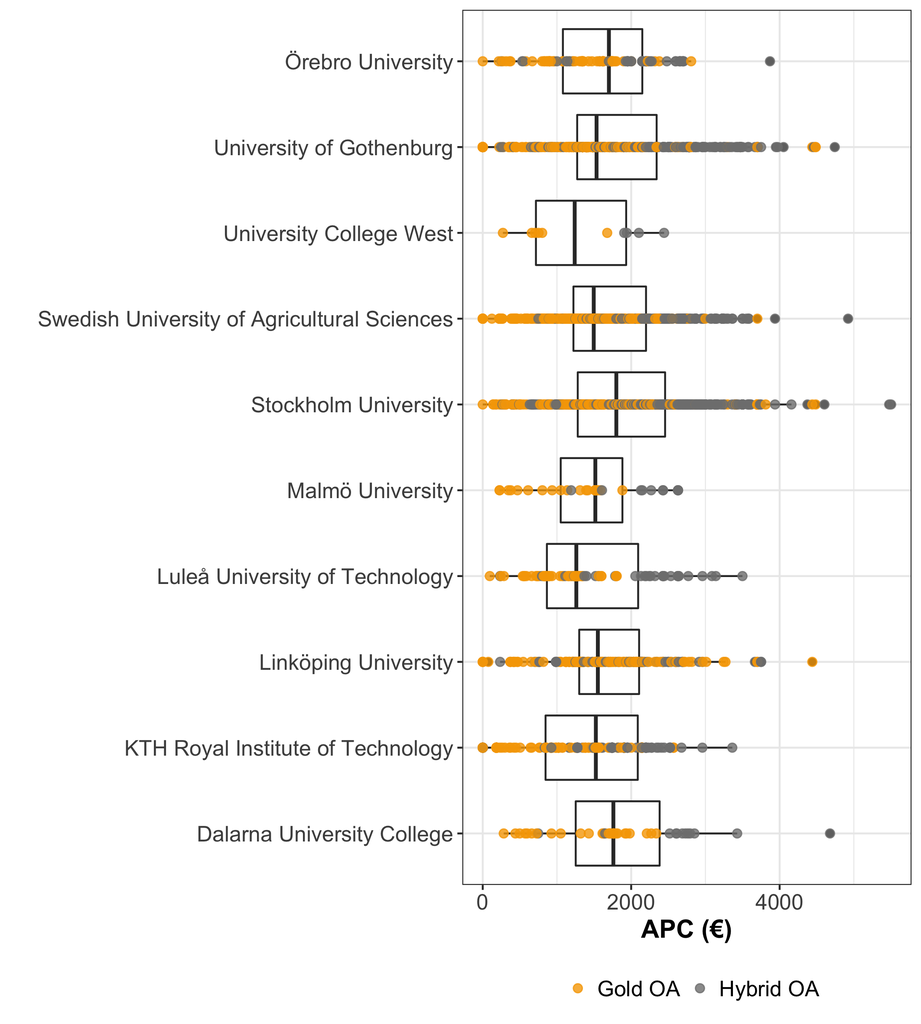

## Fees and average APC for the top-10 most frequent publishers (offset deals excluded)

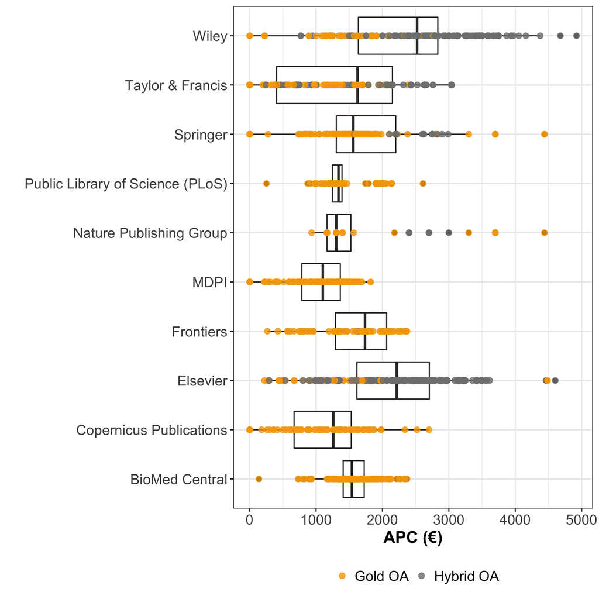

## Average and distribution of APC’s by year (offset deals excluded)

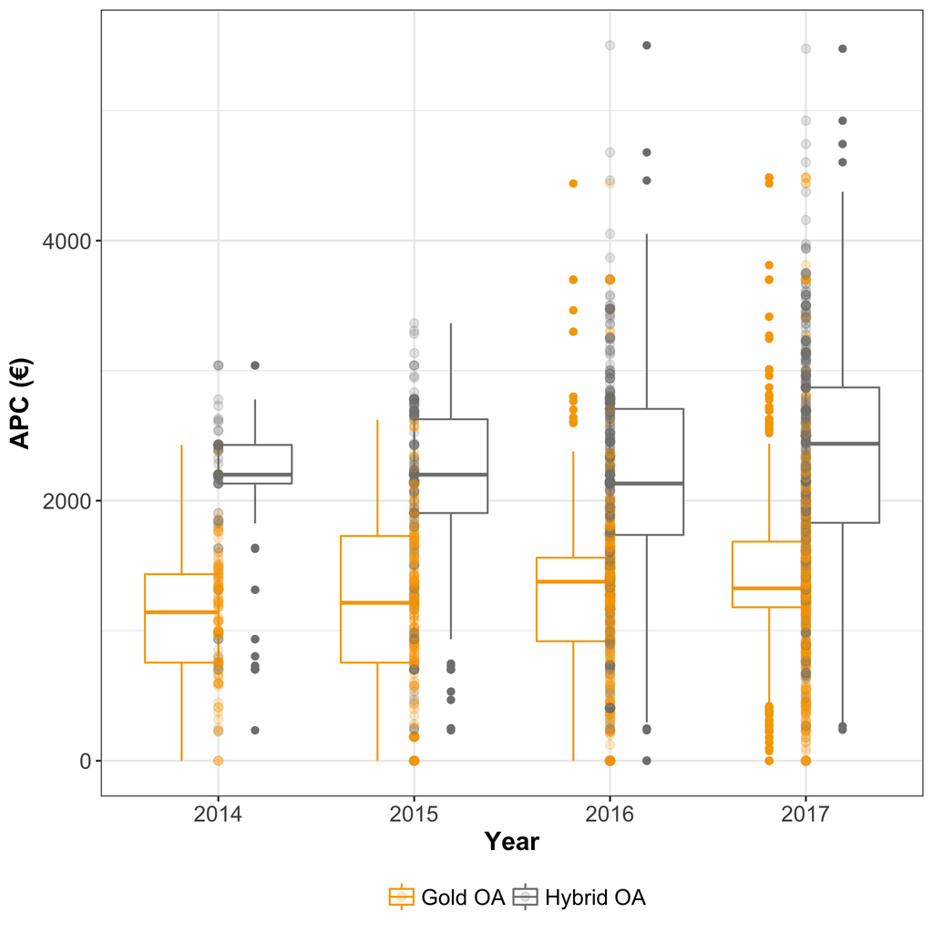

## Average APC trend by year (offset deals excluded)

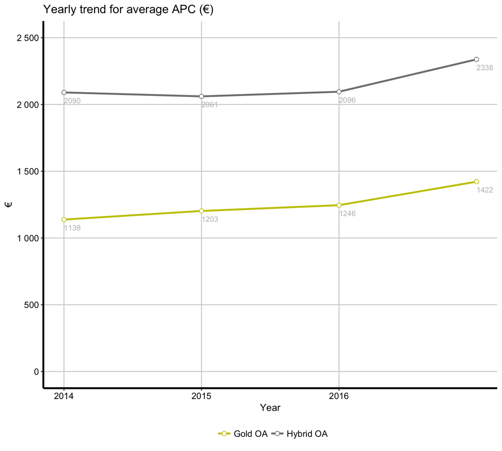

## Acknowledgement

This project follows the [Open APC Initiative](https://github.com/OpenAPC/openapc-de) to share data on paid APCs. It recognises efforts from [JISC](https://www.jisc-collections.ac.uk/Jisc-Monitor/APC-data-collection/) and [FWF](https://figshare.com/articles/Austrian_Science_Fund_FWF_Publication_Cost_Data_2014/1378610) to standardise APC reporting.

## Contact

For general comments, email Beate Eellend at the National Library of Sweden: **beate.eellend [at] kb.se**

For technical issues, email Camilla Lindelöw at the National Library of Sweden: **camilla.lindelow [at] kb.se**